[figure not shown]

This Jupyter Notebook Copyright 2016 by RESPEC, INC. All rights reserved.

$\textbf{HSP}^{\textbf{2}}\ \text{and}\ \textbf{HSP2}\ $ Copyright 2016 by RESPEC INC. and released under this License

# Calleg TEST NOTEBOOK for HSP$^2$ (WORST CASE COMPARISONS)

This Notebook will compare the results of running HSPF and HSP$^2$ for the basic hydrology (PWATER, IWATER, and HYDR) to confirm the proper calculations of HSP$^2$

Calleg is a real watershed and has

- 27 IMPLND segments,
- 129 PERLND segments,
- 119 RCHRES segments,
- 9 years of simulation time with hourly time steps (78,888 timesteps)

### Required Python imports and setup

```python
import numpy as np
import pandas as pd

pd.options.display.max_rows    = 25
pd.options.display.max_columns = 20
pd.options.display.float_format = '{:.4f}'.format  # display 2 digits after the decimal point

import matplotlib.pyplot as plt
%matplotlib inline

import hspfbintoolbox
import HSP2
import HSP2tools
HSP2tools.versions()
```

|  | Version |
| --- | --- |
| HSP2 | 0.7.2 |
| HSP2tools | 0.7.1 |
| PYTHON | 2.7.11 \| 64-bit \| (default, Jun 11 2016, 11:33... |
| IPYTHON | 5.3.0 |
| H5PY | 2.7.0 |
| MATPLOTLIB | 2.0.0 |
| NETWORKX | 1.11 |
| NUMBA | 0.31.0 |
| NUMPY | 1.11.3 |
| PANDAS | 0.19.2 |
| PYTABLES | 3.3.0 |
| WDMTOOLBOX | 0.8.2 MOD RTH |
| os | Windows-10-10.0.15063 |
| processor | Intel64 Family 6 Model 94 Stepping 3, GenuineI... |

### Setup paths to the necessary datafiles

This assumes the calleg.uci and calleg.wdm files are located in the current working directory for this Notebook. This will create the binary output file, calleg.hbn, along with a number of other standard HSPF outputs.

```python
wdmpath = 'calleg.wdm'
ucipath = 'calleg.uci'
hdfpathx = 'callegx.h5'
hdfpath = 'calleg.h5'
hbnpath = 'calleg.hbn'
```

## Run HSPF

Using the Basins 4.1 WinHspfLt executable to run calleg.uci.

This assumes the calleg.uci and calleg.wdm files are located in the current working directory for this Notebook. This will create the binary output file, calleg.hbn, along with a number of other standard HSPF outputs.

```python
!echo %date% - %time%

!C:\BASINS41\models\HSPF\bin\WinHspfLt.exe {ucipath}

!echo %date% - %time%
```

```
Fri 04/14/2017 - 16:20:53.76
Fri 04/14/2017 - 16:21:17.46
```

For development, save the best time for reference:

1 loop, best of 3: 24.4 s per loop

Now run HSP$^2$ on the calleg watershed

```python
HSP2.run(hdfpath)
```

```python
%timeit HSP2.run(hdfpath)
```

Development note: SAVEALL = FALSE (new SAVE table for hot restart by default) 2017-04-16 09:05:26.10 Run completed 1 loop, best of 3: 32.3 s per loop Ratio of HSP2/HSPF 32.3/24.4 = 1.3 SAVEALL = TRUE 2017-04-11 10:18:22.86 Run completed 1 loop, best of 3: 38.1 s per loop Ratio of HSP2/HSPF 38.1/24.4 = 1.6

## Determine Available Calculated Results

Now use Tim Cera's hspfbintoolbox.py to determine the available timeseries created by HSPF and stored into the HBN binary file.

Time interval codes: {5: 'yearly', 4: 'monthly', 3: 'daily', 2: 'bivl'}.

No daily available, so use monthly (4) timeseries for analysis.

```python
keys = hspfbintoolbox.catalog(hbnpath).keys()
keys[:5]  # show only the first 5 as a check
```

```
[(u'IMPLND', 51, u'IWATER', u'PET', 5),
 (u'PERLND', 72, u'PWATER', u'UZI', 5),
 (u'PERLND', 101, u'PWATER', u'BASET', 4),
 (u'PERLND', 242, u'PWATER', u'PERO', 4),
 (u'PERLND', 296, u'PWATER', u'SUPY', 5)]
```

## Automate checking IMPLNDs for SURO

Extract the keys (calculated above) for IMPLD + IWATER + SURO. For each key, compute several columns. The final column shows the percent difference of the sum of the SURO for the entire run between HSPF and HSP2.

```python
segments = [str(key[1]) for key in keys if key[0]=='IMPLND' and key[2]=='IWATER' and key[3]=='SURO' and key[4]==4]

dfimplnd = pd.DataFrame()
for seg in segments:
    path = 'IMPLND,' + seg + ',IWATER,SURO'
    hspf = hspfbintoolbox.extract(hbnpath, 'monthly', path).values

    path = 'RESULTS/IMPLND' + '_I' + '{:0>3s}'.format(seg) + '/IWATER'
    hsp2 = pd.read_hdf(hdfpath, path)['SURO'].resample('MS').sum().values

    #dfimplnd.at[seg, 'Max Diff'] =  (hspf - hsp2).max()
    dfimplnd.at[seg, 'Sum of HSPF'] = hspf.sum()
    dfimplnd.at[seg, 'Sum of HSP2'] = hsp2.sum()
    dfimplnd.at[seg, '%diff of Sum'] = 100.0 * (hspf.sum() - hsp2.sum()) / hspf.sum()
    dfimplnd.at[seg, 'abs(%diff of Sum)'] = 100.0 * abs(hspf.sum() - hsp2.sum()) / hspf.sum()

dfimplnd = dfimplnd.sort_values(by=['abs(%diff of Sum)'])
dfimplnd
```

|  | Sum of HSPF | Sum of HSP2 | %diff of Sum | abs(%diff of Sum) |
| --- | --- | --- | --- | --- |
| 291 | 117.5699 | 117.5699 | -0.0000 | 0.0000 |
| 281 | 137.7904 | 137.7904 | 0.0000 | 0.0000 |
| 101 | 144.1288 | 144.1288 | -0.0000 | 0.0000 |
| 21 | 122.5966 | 122.5966 | 0.0000 | 0.0000 |
| 51 | 120.2708 | 120.2708 | 0.0000 | 0.0000 |
| 81 | 118.7938 | 118.7938 | -0.0000 | 0.0000 |
| 41 | 141.2890 | 141.2890 | 0.0000 | 0.0000 |
| 271 | 136.4228 | 136.4228 | 0.0000 | 0.0000 |
| 251 | 116.6337 | 116.6337 | 0.0000 | 0.0000 |
| 201 | 172.5608 | 172.5608 | -0.0000 | 0.0000 |
| 191 | 125.6937 | 125.6937 | 0.0000 | 0.0000 |
| 221 | 126.6460 | 126.6460 | 0.0000 | 0.0000 |
| ... | ... | ... | ... | ... |
| 121 | 126.2947 | 126.2947 | 0.0000 | 0.0000 |
| 131 | 126.2947 | 126.2947 | 0.0000 | 0.0000 |
| 161 | 131.2695 | 131.2695 | 0.0000 | 0.0000 |
| 211 | 125.3008 | 125.3008 | -0.0000 | 0.0000 |
| 11 | 131.6821 | 131.6821 | 0.0000 | 0.0000 |
| 61 | 133.6036 | 133.6036 | 0.0000 | 0.0000 |
| 151 | 133.6036 | 133.6036 | 0.0000 | 0.0000 |
| 301 | 119.8081 | 119.8081 | -0.0000 | 0.0000 |
| 171 | 115.9610 | 115.9610 | 0.0000 | 0.0000 |
| 181 | 115.9610 | 115.9610 | 0.0000 | 0.0000 |
| 241 | 120.2066 | 120.2066 | 0.0000 | 0.0000 |
| 231 | 135.5890 | 135.5890 | 0.0000 | 0.0000 |

27 rows × 4 columns

Look at the statistics for the percent difference column

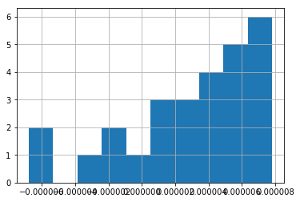

```python
dfimplnd['%diff of Sum'].hist()
```

```python
dfimplnd['%diff of Sum'].describe()
```

```
count   27.0000
mean     0.0000
std      0.0000
min     -0.0000
25%      0.0000
50%      0.0000
75%      0.0000
max      0.0000
Name: %diff of Sum, dtype: float64
```

```python
ils = dfimplnd.index[-1]
print 'WORST IMPLND SEGMENT IS', ils
print '%diff of the total SURO sum of', dfimplnd.loc[ils,'%diff of Sum']
```

```
WORST IMPLND SEGMENT IS 231
%diff of the total SURO sum of 7.81454022292e-06
```

### Define a function to read HSPF and HSP2 data, and plot together for IMPLND

```python
def imp(ils, name, how='sum'):
    # Use Tim Cera's HBN reader to get the HSPF data
    path = 'IMPLND,' + str(ils) + ',IWATER,' + name
    hspf = hspfbintoolbox.extract(hbnpath, 'monthly', path)

    # Now read the corresponding HSP2 data and comvert to monthly, MS (Month Start) to match hspfbintoolbox data.
    path = '/RESULTS/IMPLND' + '_I' + '{:0>3s}'.format(str(ils)) + '/IWATER'
    hsp2 = pd.read_hdf(hdfpath, path)
    if how == 'sum':
        hsp2 = hsp2.resample('MS').sum()
    elif how == 'last':
        hsp2 = hsp2.resample('MS').last()

    hsp2 = hsp2[name]

    plt.figure(figsize=(10,8))
    plt.plot(hspf.index, hspf, label='HSPF', color='r')
    plt.plot(hsp2.index, hsp2, label='HSP2', color='b')
    plt.legend()
    plt.title('IMPLND ' + 'I' + '{:0>3s}'.format(str(ils)) + ', IWATER ' +  name)

    return hspf, hsp2
```

#### IMPLND IWATER SURO, Monthly

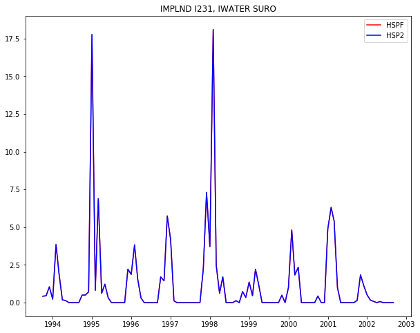

```python
hspf, hsp2 = imp(ils, 'SURO', 'sum')
```

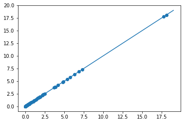

```python
plt.scatter(hspf, hsp2)
top = 1.05 * max(hspf.values.max(), hsp2.values.max())
plt.plot([0.0, top], [0.0, top])
```

#### IMPLND IWATER IMPEV, Monthly

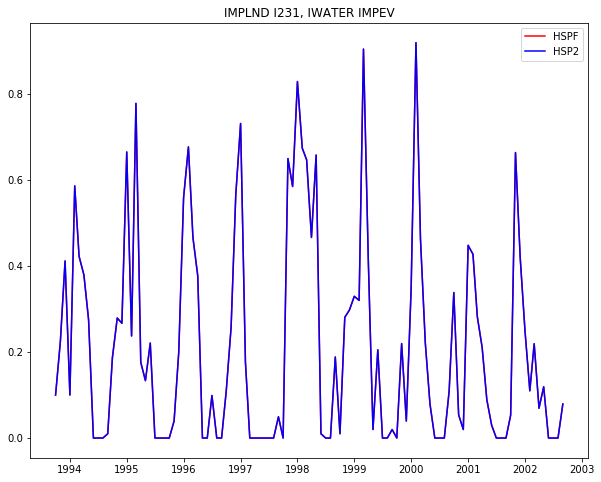

```python
hspf, hsp2 = imp(ils, 'IMPEV')
```

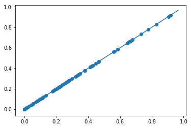

```python
plt.scatter(hspf, hsp2)
top = 1.05 * max(hspf.values.max(), hsp2.values.max())
plt.plot([0.0, top], [0.0, top])
```

#### IMPLND IWATER PET, Monthly

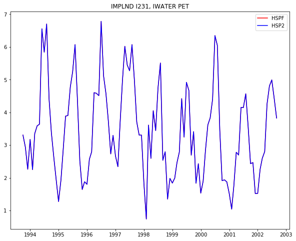

```python
hspf, hsp2 = imp(ils, 'PET')
```

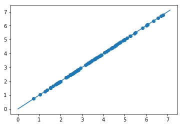

```python
plt.scatter(hspf, hsp2)
top = 1.05 * max(hspf.values.max(), hsp2.values.max())
plt.plot([0.0, top], [0.0, top])
```

#### IMPLND IWATER RETS, Monthly

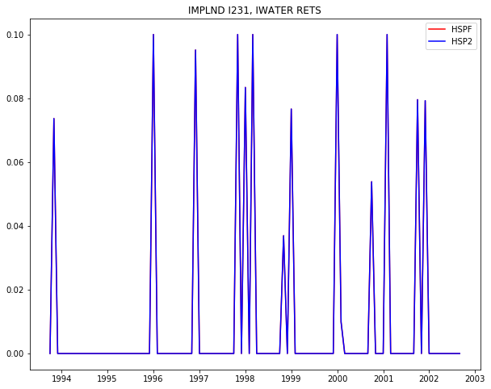

```python
hspf, hsp2 = imp(ils, 'RETS', 'last')
```

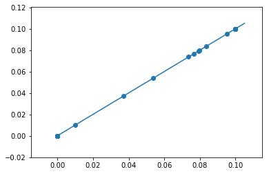

```python
plt.scatter(hspf, hsp2)
top = 1.05 * max(hspf.values.max(), hsp2.values.max())
plt.plot([0.0, top], [0.0, top])
```

#### IMPLND IWATER SUPY, Monthly

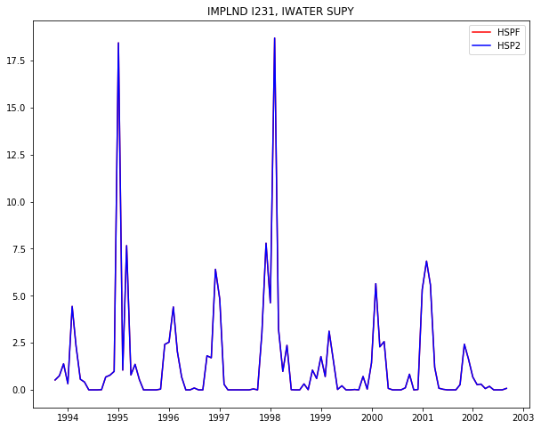

```python
hspf, hsp2 = imp(ils, 'SUPY')
```

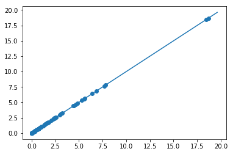

```python
plt.scatter(hspf, hsp2)
top = 1.05 * max(hspf.values.max(), hsp2.values.max())
plt.plot([0.0, top], [0.0, top])
```

#### IMPLND IWATER SURS, Monthly

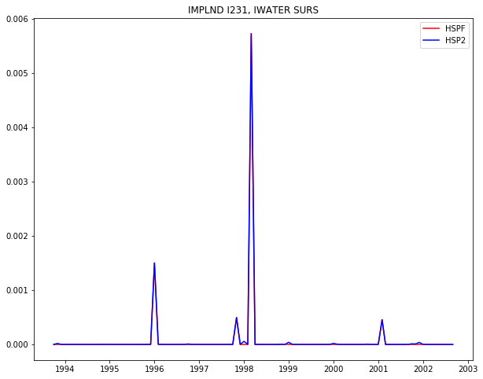

```python
hspf, hsp2 = imp(ils, 'SURS', 'last')
```

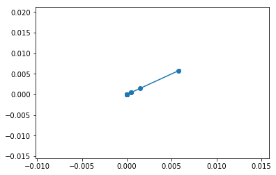

```python
plt.scatter(hspf, hsp2)
top = 1.05 * max(hspf.values.max(), hsp2.values.max())
plt.plot([0.0, top], [0.0, top])
```

## Automate checking PERLNDs for PERO

### Define routine to read HSPF and HSP2 data and plot together

```python
def per(pls, name, how='sum'):
    # Use Tim Cera's HBN reader to get the HSPF data
    path = 'PERLND,' + str(pls) + ',PWATER,' + name
    hspf = hspfbintoolbox.extract(hbnpath, 'monthly', path)

    # Now read the corresponding HSP2 data and comvert to monthly
    path = '/RESULTS/PERLND' +  '_P' + '{:0>3s}'.format(str(pls)) + '/PWATER'
    if how == 'sum':
        hsp2 = pd.read_hdf(hdfpath, path)[name].resample('MS').sum()
    elif how == 'last':
        hsp2 = pd.read_hdf(hdfpath, path)[name].resample('MS').last()

    plt.figure(figsize=(10,8))
    plt.plot(hspf.index, hspf, label='HSPF', color='r')
    plt.plot(hsp2.index, hsp2, label='HSP2', color='b')
    plt.legend()
    plt.title('PERLND ' + 'P' + '{:0>3s}'.format(str(pls))+ ', PWATER ' +  name)

    return hspf, hsp2
```

### Now find all available monthly data

```python
segments = [str(key[1]) for key in keys if key[0]=='PERLND' and key[2]=='PWATER' and key[3]=='PERO' and key[4]==4]

dfperlnd = pd.DataFrame()
for seg in segments:
    path = 'PERLND,' + seg + ',PWATER,PERO'
    hspf = hspfbintoolbox.extract(hbnpath, 'monthly', path).values

    path =  'RESULTS/PERLND' +  '_P' + '{:0>3s}'.format(str(seg)) + '/PWATER'
    hsp2 = pd.read_hdf(hdfpath, path)['PERO'].resample('MS').sum().values

    #dfperlnd.at[seg, 'Max Diff'] =  (hspf - hsp2).max()
    dfperlnd.at[seg, 'Sum of HSPF'] = hspf.sum()
    dfperlnd.at[seg, 'Sum of HSP2'] = hsp2.sum()
    dfperlnd.at[seg, '%diff of Sum'] = 100.0 * (hspf.sum() - hsp2.sum()) / hspf.sum()
    dfperlnd.at[seg, 'abs(%diff of Sum)'] = 100.0 * abs(hspf.sum() - hsp2.sum()) / hspf.sum()

dfperlnd = dfperlnd.sort_values(by=['abs(%diff of Sum)'])
dfperlnd
```

|  | Sum of HSPF | Sum of HSP2 | %diff of Sum | abs(%diff of Sum) |
| --- | --- | --- | --- | --- |
| 55 | 64.7859 | 64.7859 | -0.0000 | 0.0000 |
| 226 | 29.4270 | 29.4270 | -0.0000 | 0.0000 |
| 222 | 45.9145 | 45.9145 | -0.0000 | 0.0000 |
| 124 | 56.8129 | 56.8129 | -0.0000 | 0.0000 |
| 235 | 85.6543 | 85.6543 | -0.0000 | 0.0000 |
| 71 | 13.8709 | 13.8709 | -0.0000 | 0.0000 |
| 275 | 44.8519 | 44.8519 | 0.0000 | 0.0000 |
| 135 | 49.4472 | 49.4472 | -0.0000 | 0.0000 |
| 23 | 57.9035 | 57.9035 | -0.0000 | 0.0000 |
| 201 | 10.9715 | 10.9715 | -0.0000 | 0.0000 |
| 82 | 45.8386 | 45.8386 | 0.0000 | 0.0000 |
| 285 | 97.2314 | 97.2315 | -0.0000 | 0.0000 |
| ... | ... | ... | ... | ... |
| 182 | 34.9727 | 34.9728 | -0.0001 | 0.0001 |
| 234 | 80.8644 | 80.8645 | -0.0001 | 0.0001 |
| 243 | 61.3994 | 61.3993 | 0.0001 | 0.0001 |
| 251 | 6.8682 | 6.8682 | -0.0001 | 0.0001 |
| 286 | 36.9911 | 36.9912 | -0.0002 | 0.0002 |
| 152 | 34.4905 | 34.4905 | -0.0002 | 0.0002 |
| 111 | 7.1259 | 7.1259 | 0.0002 | 0.0002 |
| 195 | 78.4795 | 78.4794 | 0.0002 | 0.0002 |
| 306 | 72.7248 | 72.7249 | -0.0002 | 0.0002 |
| 125 | 59.8035 | 59.8037 | -0.0003 | 0.0003 |
| 185 | 14.7898 | 14.7901 | -0.0025 | 0.0025 |
| 101 | 6.1333 | 6.1325 | 0.0128 | 0.0128 |

129 rows × 4 columns

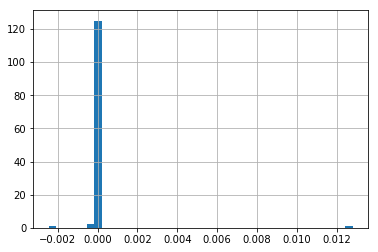

```python
dfperlnd['%diff of Sum'].hist(bins=40)
```

```python
dfperlnd['%diff of Sum'].describe()
```

```
count   129.0000
mean      0.0001
std       0.0012
min      -0.0025
25%      -0.0001
50%      -0.0000
75%      -0.0000
max       0.0128
Name: %diff of Sum, dtype: float64
```

The PERLND segments are ordered in assending "abs(%diff of Sum)", so the last entry is the worst case (by this measure.)

```python
pls = dfperlnd.index[-1]
print 'WORST PERLND SEGMENT IS', pls
print '%diff of the total PERO sum of', dfperlnd.loc[pls,'%diff of Sum']
```

```
WORST PERLND SEGMENT IS 101
%diff of the total PERO sum of 0.0128203408491
```

#### PERLND PWATER AGWO

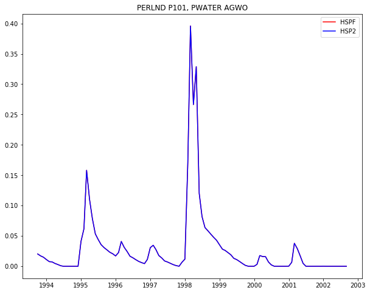

```python
hspf, hsp2 = per(pls, 'AGWO')
```

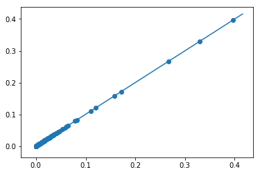

```python
plt.scatter(hspf, hsp2)
top = 1.05 * max(hspf.values.max(), hsp2.values.max())
plt.plot([0.0, top], [0.0, top])
```

#### PERLND PWATER BASET

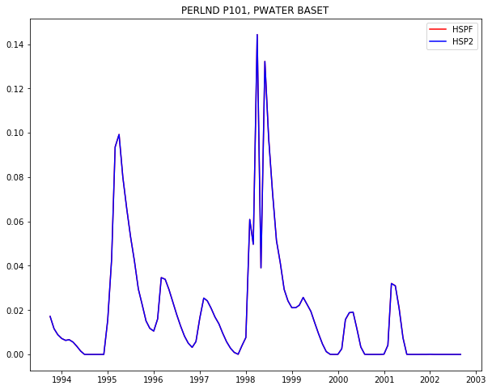

```python
hspf, hsp2 = per(pls, 'BASET')
```

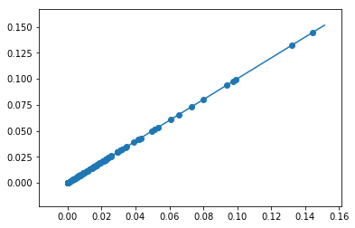

```python
plt.scatter(hspf, hsp2)
top = 1.05 * max(hspf.values.max(), hsp2.values.max())
plt.plot([0.0, top], [0.0, top])
```

##### PERLND PWATER CEPE

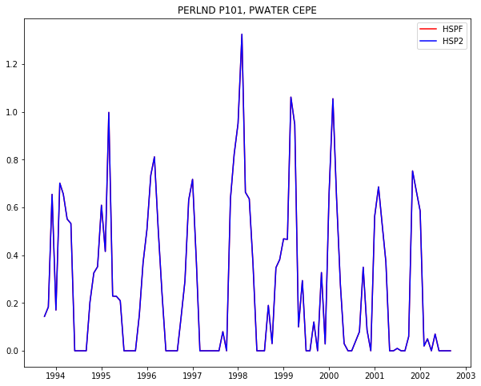

```python
hspf, hsp2 = per(pls, 'CEPE')
```

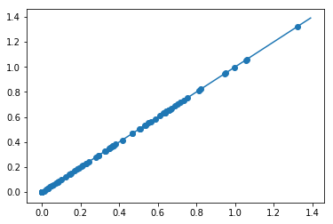

```python
plt.scatter(hspf, hsp2)
top = 1.05 * max(hspf.values.max(), hsp2.values.max())
plt.plot([0.0, top], [0.0, top])
```

#### PERLND PWATER IFWI

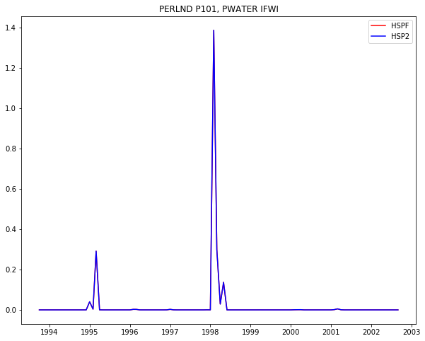

```python
hspf, hsp2 = per(pls, 'IFWI')
```

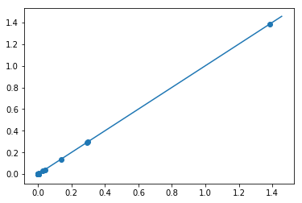

```python
plt.scatter(hspf, hsp2)
top = 1.05 * max(hspf.values.max(), hsp2.values.max())
plt.plot([0.0, top], [0.0, top])
```

#### PERLND PWATER IFWO

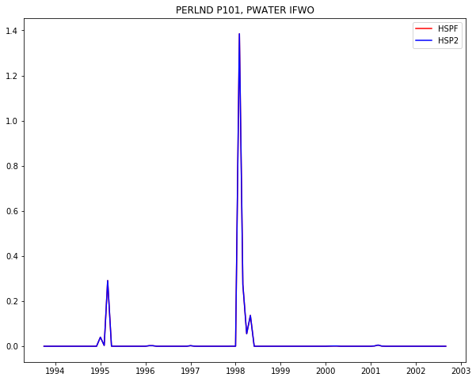

```python
hspf, hsp2 = per(pls, 'IFWO')
```

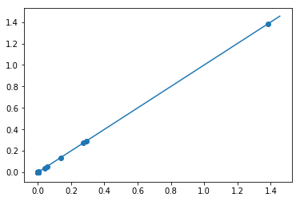

```python
plt.scatter(hspf, hsp2)
top = 1.05 * max(hspf.values.max(), hsp2.values.max())
plt.plot([0.0, top], [0.0, top])
```

#### PERLND PWATER IGWI

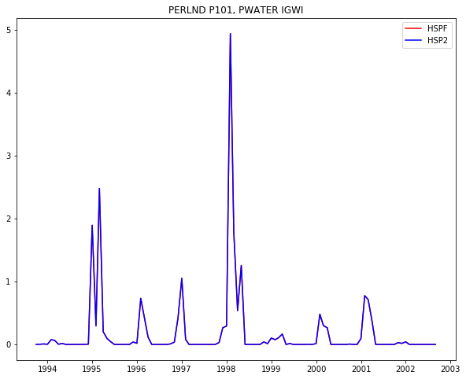

```python
hspf, hsp2 = per(pls, 'IGWI')
```

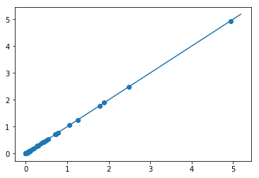

```python
plt.scatter(hspf, hsp2)
top = 1.05 * max(hspf.values.max(), hsp2.values.max())
plt.plot([0.0, top], [0.0, top])
```

#### PERLND PWATER INFIL

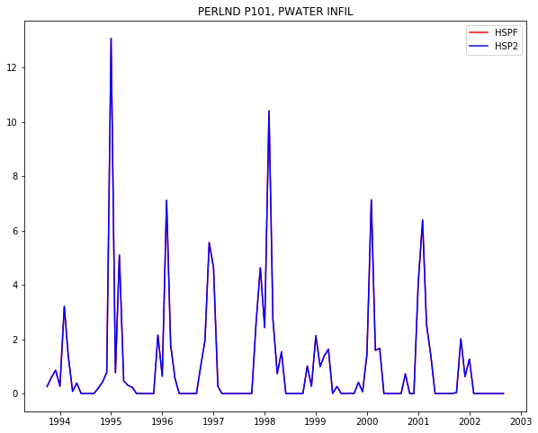

```python
hspf, hsp2 = per(pls, 'INFIL')
```

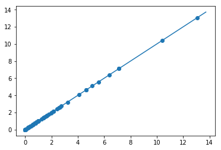

```python
plt.scatter(hspf, hsp2)
top = 1.05 * max(hspf.values.max(), hsp2.values.max())
plt.plot([0.0, top], [0.0, top])
```

#### PERLND PWATER LZET

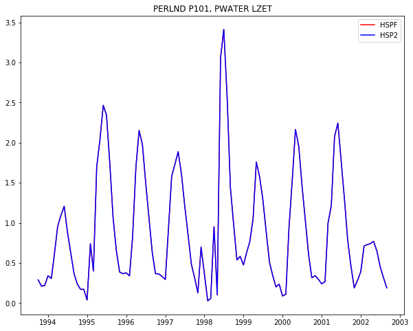

```python
hspf, hsp2 = per(pls, 'LZET')
```

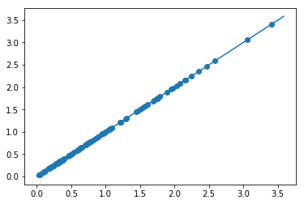

```python
plt.scatter(hspf, hsp2)
top = 1.05 * max(hspf.values.max(), hsp2.values.max())
plt.plot([0.0, top], [0.0, top])
```

#### PERLND PWATER PERC

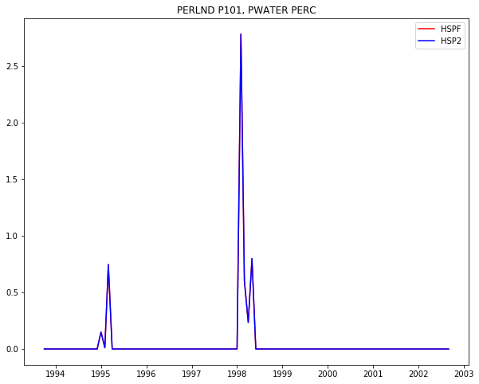

```python
hspf, hsp2 = per(pls, 'PERC')
```

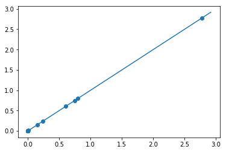

```python
plt.scatter(hspf, hsp2)
top = 1.05 * max(hspf.values.max(), hsp2.values.max())
plt.plot([0.0, top], [0.0, top])
```